# Urosalpinx growth rate (length)

## Quadratic

One reason we are checking quadratic is that sometimes the optima isn’t the optima! If you closely examine the segmented regressions, you see that in some cases the second segment’s slope does not appear to be negative. Instead, it plateaus. This raises the question whether we can really define our breakpoint as optima. Potentially, we could interpret the breakpoints as the lowest temperature of maximum growth. At any rate, one idea is to redo all the analysis we just did for segmented regression but with a quadratic model, and seeing if we get a similar result in both the stacking but also the trends of the maximal growth and optima as we did with the segmented regression.

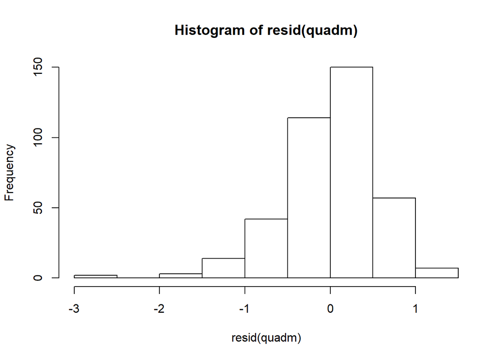

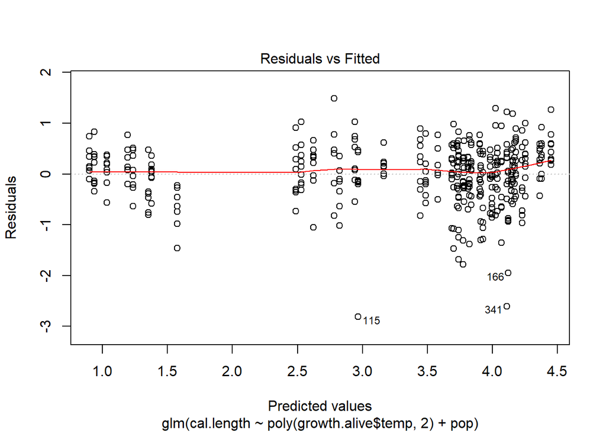

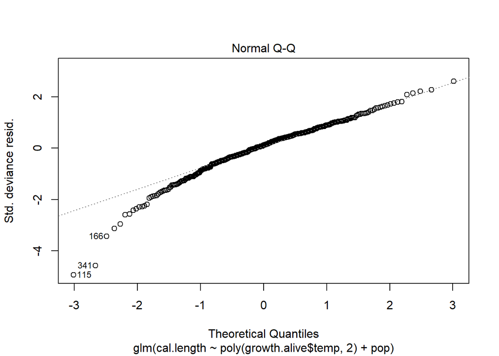

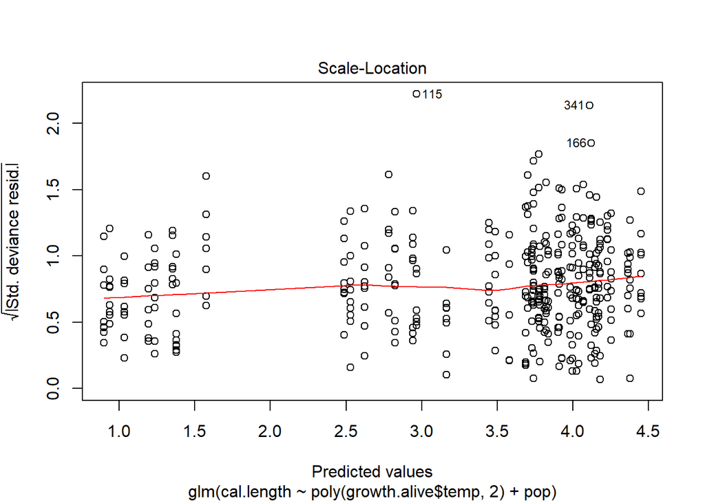

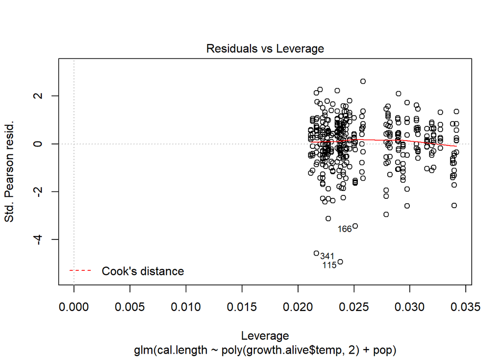

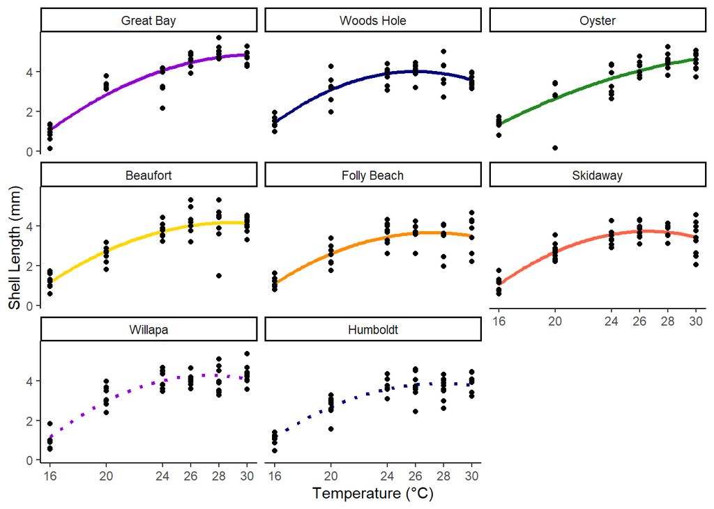

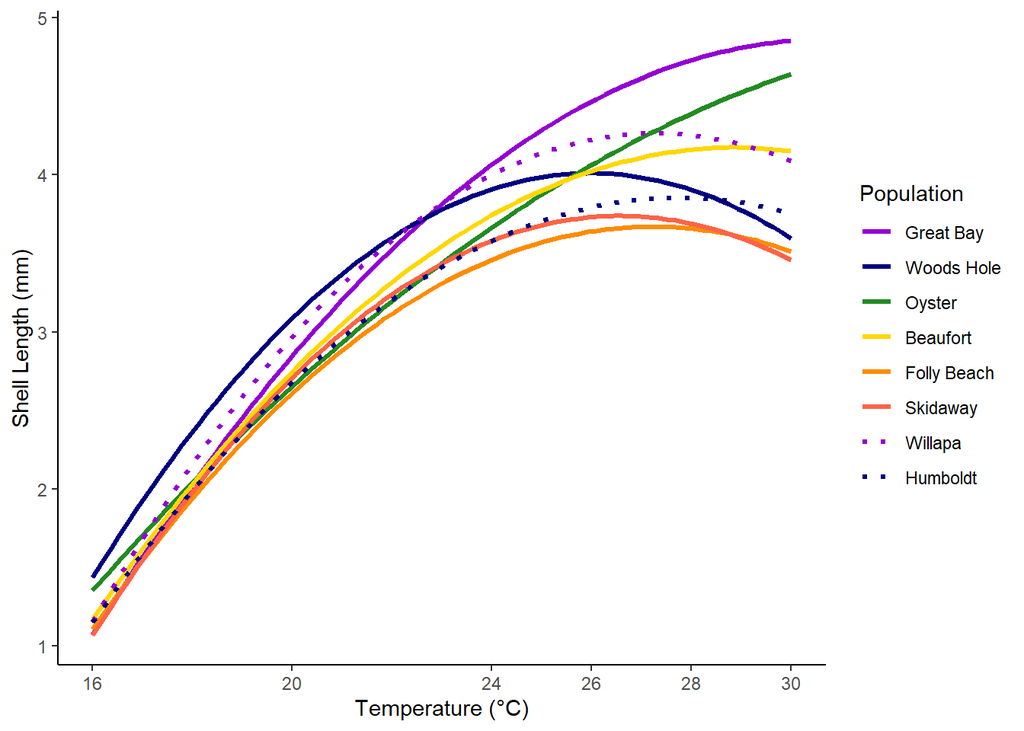

Here, we see more or less similar patterns of cold pops stacked on warm pops. How do the breakpoints stack up?

Before we extract quadratic breakpoints, let’s line up segmented regression and quadratic regression and see if they look close. The curves do match up nicely, but the breakpoints will be different.

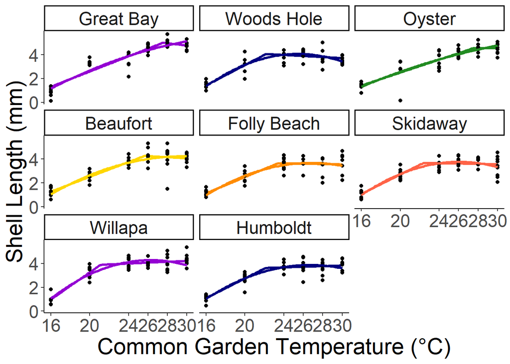